# Tracking republican party changes

2025-03-25

# Calculate net change in Republican-controlled seats per state between 2021-2024

```r
library(readr)
library(dplyr)
changes_rep <- read_csv("All_Years_Combined.csv")
```

[output not shown]

```r
changes_filtered <- changes_rep %>%
  filter(Year %in% c(2021, 2024))

changes_filtered <- changes_filtered %>%
  mutate(Senate.Rep = as.numeric(Senate.Rep),
         House.Rep = as.numeric(House.Rep)
         )

changes_filtered <- changes_filtered %>%
  mutate(Total_Rep = Senate.Rep + House.Rep)

# Reshaping so each state's Rep seat counts for 2021 and 2024 are in separate columns

library(tidyr)



changes_wide <- changes_filtered %>%
  select(STATE, Year, Total_Rep) %>%
  pivot_wider(names_from = Year, values_from = Total_Rep, names_prefix = "Year_")

# Calculate net changes - difference in Rep seats between 2024 and 2021
changes_wide <- changes_wide %>%
  mutate(Net_Change = Year_2024 - Year_2021)

print(changes_wide)
```

```
## # A tibble: 50 × 4
##    STATE       Year_2021 Year_2024 Net_Change
##    <chr>           <dbl>     <dbl>      <dbl>
##  1 Alabama           103       103          0
##  2 Alaska             34        32         -2
##  3 Arizona            47        50          3
##  4 Arkansas          105       110          5
##  5 California         28        30          2
##  6 Colorado           39        33         -6
##  7 Connecticut        66        60         -6
##  8 Delaware           22        20         -2
##  9 Florida           102       113         11
## 10 Georgia           137       133         -4
## # ℹ 40 more rows
```

```r
# Sort by net change
changes_wide_sorted <- changes_wide %>%
  arrange(desc(Net_Change))
print(changes_wide_sorted)
```

```
## # A tibble: 50 × 4
##    STATE          Year_2021 Year_2024 Net_Change
##    <chr>              <dbl>     <dbl>      <dbl>
##  1 West Virginia        100       123         23
##  2 Vermont               53        69         16
##  3 Florida              102       113         11
##  4 Iowa                  91       102         11
##  5 New Hampshire        227       238         11
##  6 South Carolina       111       122         11
##  7 Maine                 79        88          9
##  8 Hawaii                 5        12          7
##  9 Louisiana             94       101          7
## 10 Texas                101       108          7
## # ℹ 40 more rows
```

W. Virginia, Vermont, Florida, Iowa, New Hampshire, S. Carolina, Maine, Hawaii, Louisiana, Texas, Kansas, New York, Wyoming, Arkansas, Kentucky, N. Dakota, Virginia, Idaho, Mississippi, N. Carolina, Arizona, New Mexico, Utah, California, Minnesota, Oregon, S. Dakota, Tennessee had net positive changes (became more republican controlled in 3 years)

# Visualizing net change in Republican seats

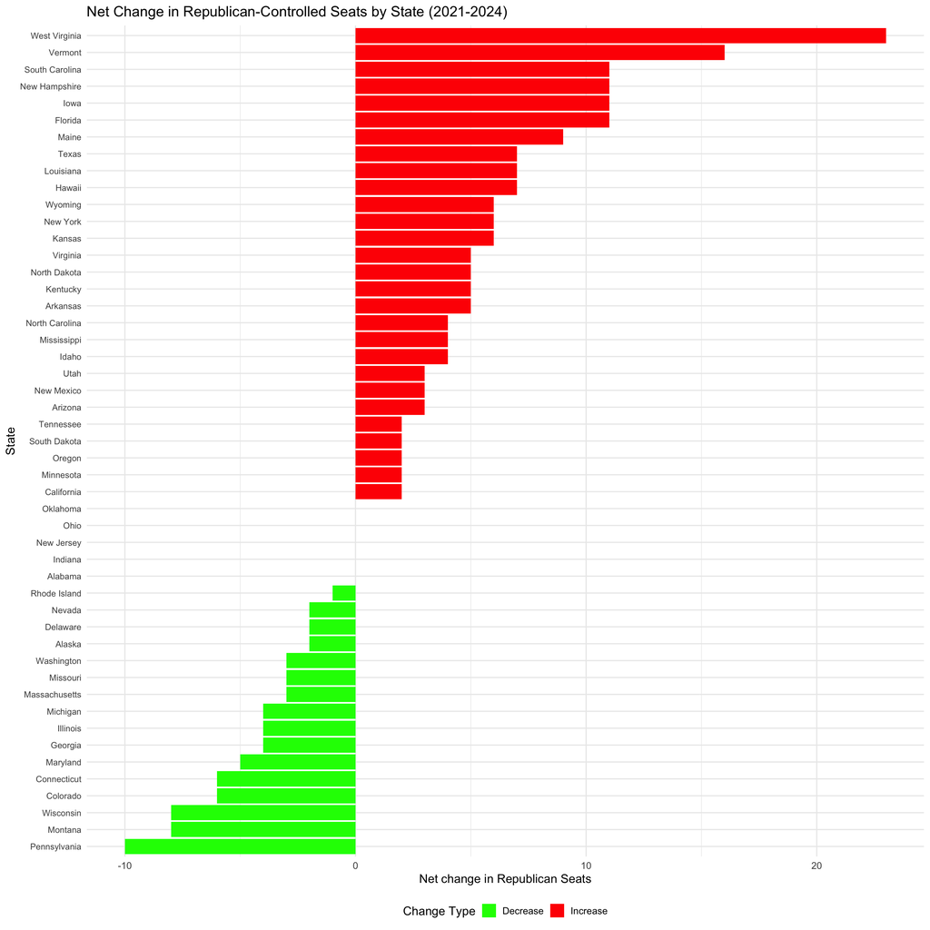

```r
library(ggplot2)
changes_wide_sorted %>%
         filter(STATE != "Nebraska") %>%
         ggplot(aes(x = reorder(STATE, Net_Change), y = Net_Change, fill = Net_Change > 0)) +
  geom_col() +
  coord_flip() +
  scale_fill_manual(values = c("TRUE" = "red", "FALSE" = "green"),
                    labels = c("Decrease", "Increase")) +
  labs(
    title = "Net Change in Republican-Controlled Seats by State (2021-2024)",
    x = "State",
    y = "Net change in Republican Seats",
    fill = "Change Type"
  ) +
  theme_minimal(base_size = 14) +
  theme(
    axis.text.y = element_text(size = 10),
    legend.position = "bottom"
  )
```

# Net changes in Democratic-Controlled Seats (2021-2024)

```r
changes_dem <- read_csv("All_Years_Combined.csv")
```

```
## ──────────────────────────────────────────────────────── Delimiter: "," chr
## (7): STATE, Senate other, Total House, House other, Leg.Control, Gov.Par... dbl
## (8): ...1, Total.Seats, Total.Senate , Senate.Dem, Senate.Rep, House.Dem...
```

```r
changes_filtered_dem <- changes_dem %>%
  filter(Year %in% c(2021, 2024))

changes_filtered_dem <- changes_filtered_dem %>%
  mutate(
    Senate.Dem = as.numeric(Senate.Dem),
    House.Dem = as.numeric(House.Dem)
  )

# Total Dem seats
changes_filtered_dem <- changes_filtered_dem %>%
  mutate(Total_Dem = Senate.Dem + House.Dem)

changes_wide_dem <- changes_filtered_dem %>%
  select(STATE, Year, Total_Dem) %>%
  pivot_wider(names_from = Year, values_from = Total_Dem, names_prefix = "Year_")


# Net changes in Dem seats
changes_wide_dem <- changes_wide_dem %>%
  mutate(Net_Change = Year_2024 - Year_2021)

changes_wide_dem <- changes_wide_dem %>%
  filter(STATE != "Nebraska")

# sort by net change
changes_wide_sorted_dem <- changes_wide_dem %>%
  arrange(desc(Net_Change))

print(changes_wide_sorted_dem)
```

```
## # A tibble: 49 × 4
##    STATE         Year_2021 Year_2024 Net_Change
##    <chr>             <dbl>     <dbl>      <dbl>
##  1 Pennsylvania        111       124         13
##  2 Wisconsin            50        60         10
##  3 Montana              52        60          8
##  4 Connecticut         120       127          7
##  5 Colorado             61        67          6
##  6 Georgia              98       103          5
##  7 Maryland            131       136          5
##  8 Illinois            114       118          4
##  9 Massachusetts       165       169          4
## 10 Michigan             68        72          4
## # ℹ 39 more rows
```

# Plot net change in Dem-controlled seats

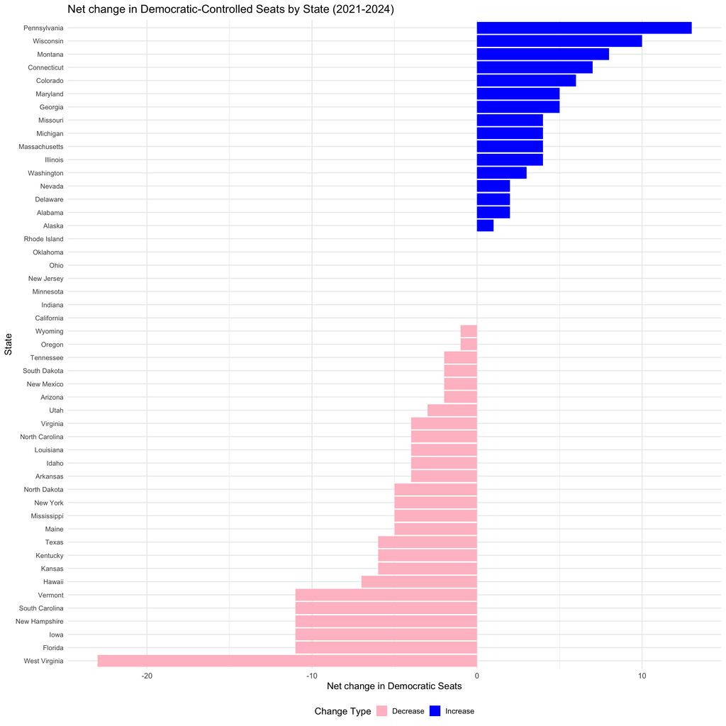

```r
ggplot(changes_wide_sorted_dem, aes(x = reorder(STATE, Net_Change), y = Net_Change, fill = Net_Change > 0)) +
  geom_col() +
  coord_flip() +
  scale_fill_manual(
    values = c("TRUE"= "blue", "FALSE" = "pink"),
    labels = c("FALSE" = "Decrease", "TRUE" = "Increase")
    ) +
  labs(
    title = "Net change in Democratic-Controlled Seats by State (2021-2024)",
    x = "State",
    y = "Net change in Democratic Seats",
    fill = "Change Type"
  ) +
  theme_minimal(base_size = 14) +
  theme(
    axis.text.y = element_text(size = 10),
    legend.position = "bottom"
  )
```

# Changes in State Control from 2021 to 2024

```r
state_c <- read_csv("All_Years_Combined.csv")
```

```
## ──────────────────────────────────────────────────────── Delimiter: "," chr
## (7): STATE, Senate other, Total House, House other, Leg.Control, Gov.Par... dbl
## (8): ...1, Total.Seats, Total.Senate , Senate.Dem, Senate.Rep, House.Dem...
```

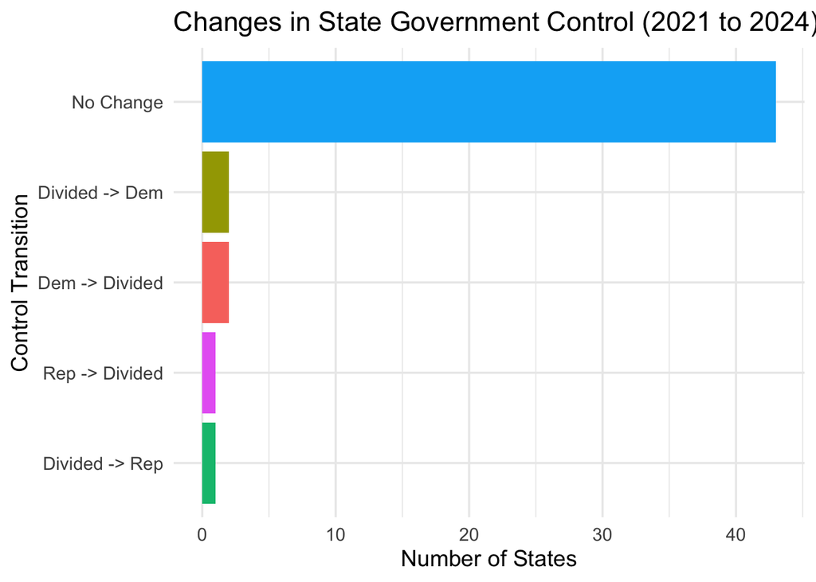

```r
state_c_filtered <- state_c %>%
  filter(Year %in% c(2021, 2024)) %>%
  select(STATE, Year, State.Control)

state_control_wide <- state_c_filtered %>%
  pivot_wider(names_from = Year, values_from = State.Control, names_prefix = "Year_")

# remove Nebraska
state_control_wide <- state_control_wide %>%
  filter(STATE != "Nebraska")

# New column for change
  state_control_wide <- state_control_wide %>%
    mutate(Change = ifelse(Year_2021 == Year_2024, "No Change",
                         paste(Year_2021, "->", Year_2024)))

change_counts <- state_control_wide %>%
  count(Change)

ggplot(change_counts, aes(x = reorder(Change, n), y = n, fill = Change)) +
  geom_col(show.legend = FALSE) +
  coord_flip() +
  labs(
    title = "Changes in State Government Control (2021 to 2024)",
    x = "Control Transition",
    y = "Number of States"
  ) +
  theme_minimal(base_size = 14)
```

Most states did not experience a change in government control when comparing 2024 to 2021

# Show which states made which transitions

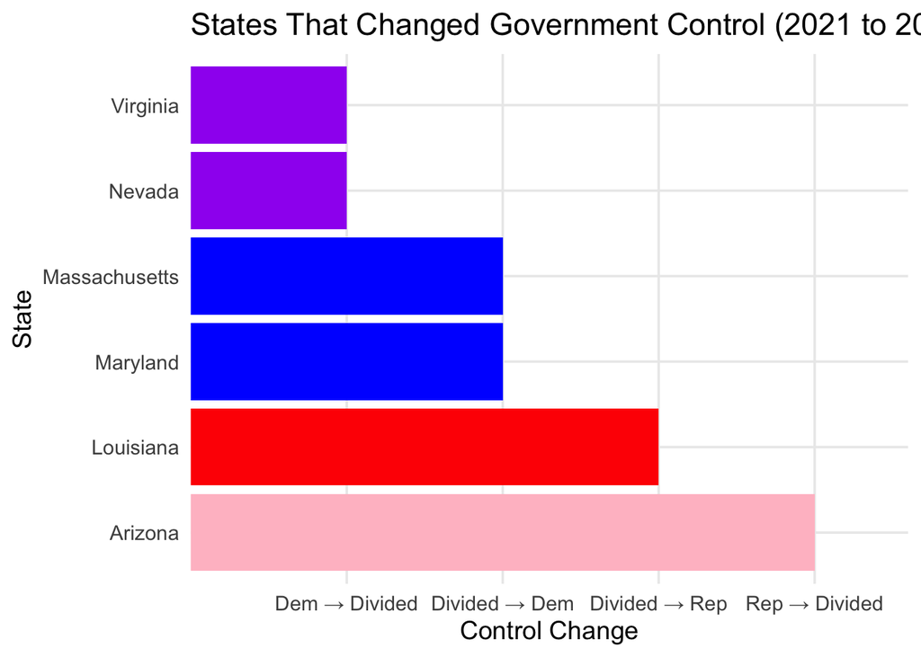

```r
state_c_filtered <- state_c %>%
  filter(Year %in% c(2021, 2024)) %>%
  select(STATE, Year, State.Control)


state_control_wide <- state_c_filtered %>%
  pivot_wider(names_from = Year, values_from = State.Control, names_prefix = "Year_")

# Remove Nebraska (nonpartisan)
state_control_wide <- state_control_wide %>%
  filter(STATE != "Nebraska")

# Create 'Change' label
state_control_wide <- state_control_wide %>%
  mutate(Change = ifelse(Year_2021 == Year_2024, "No Change",
                         paste(Year_2021, "→", Year_2024)))

# Plot: Which states changed and how
ggplot(state_control_wide %>% filter(Change != "No Change"),
       aes(x = reorder(STATE, Change), y = Change, fill = Change)) +
  geom_col(show.legend = FALSE) +
  coord_flip() +
  scale_fill_manual(values = c(
    "Divided→Rep" = "red",
    "Divided → Rep" = "red",
    "Divided→Dem" = "blue",
    "Divided → Dem" = "blue",
    "Dem→Divided" = "purple",
    "Dem → Divided" = "purple",
    "Rep→Divided" = "pink",
    "Rep → Divided" = "pink"
  )) +
  labs(
    title = "States That Changed Government Control (2021 to 2024)",
    x = "State",
    y = "Control Change"
  ) +
  theme_minimal(base_size = 14)
```

In 2021, Virginia and Nevada Democrats had control but in 2024 government was divided. In 2021, Massachusetts and Maryland were Divided and in 2024 Democrats had control. In 2021, Louisiana was divided but went into Republcian control in 2024. Arizona was Republican controlled in 2021, divided in 2024

# Find which year had most Republican state governments

```r
state_data <- read_csv("All_Years_Combined.csv")
```

```
## ──────────────────────────────────────────────────────── Delimiter: "," chr
## (7): STATE, Senate other, Total House, House other, Leg.Control, Gov.Par... dbl
## (8): ...1, Total.Seats, Total.Senate , Senate.Dem, Senate.Rep, House.Dem...
```

```r
rep_control_by_year <- state_data %>%
  filter(State.Control == "Rep") %>%
  group_by(Year) %>%
  summarise(Num_Rep_States = n()) %>%
  arrange(desc(Num_Rep_States))

print(rep_control_by_year)
```

```
## # A tibble: 4 × 2
##    Year Num_Rep_States
##   <dbl>          <int>
## 1  2021             23
## 2  2022             23
## 3  2024             23
## 4  2023             22
```

2021, 2022, 2024 - 23 states had Republican governments. 2023 drop to 22. Not really significant finding here in increased conservatism.

```r
# Remove Nebraska (nonpartisan)
state_data <- state_data %>%
  filter(STATE != "Nebraska")

# Count number of states under each control type by year
state_control_trend_yearly <- state_data %>%
  group_by(Year, State.Control) %>%
  summarise(Num_States = n(), .groups = "drop")

# View summary (optional)
print(state_control_trend_yearly)
```

```
## # A tibble: 12 × 3
##     Year State.Control Num_States
##    <dbl> <chr>              <int>
##  1  2021 Dem                   15
##  2  2021 Divided               11
##  3  2021 Rep                   23
##  4  2022 Dem                   14
##  5  2022 Divided               12
##  6  2022 Rep                   23
##  7  2023 Dem                   17
##  8  2023 Divided               10
##  9  2023 Rep                   22
## 10  2024 Dem                   15
## 11  2024 Divided               11
## 12  2024 Rep                   23
```

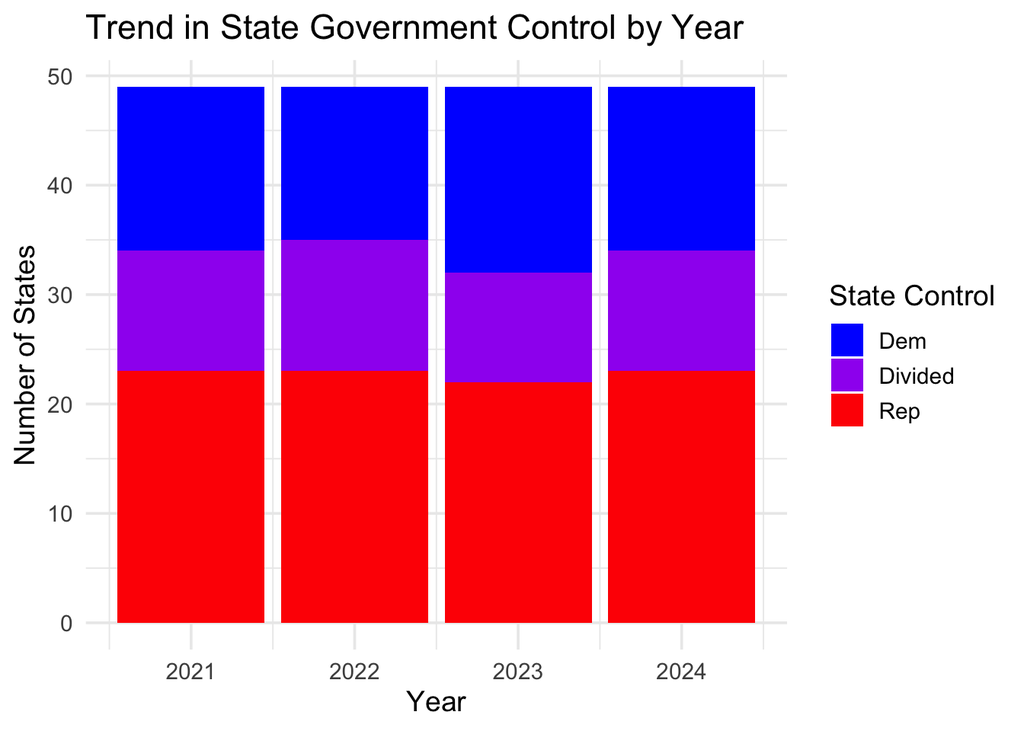

```r
# Plot the trend over time
ggplot(state_control_trend_yearly, aes(x = Year, y = Num_States, fill = State.Control)) +
  geom_col(position = "stack") +
  scale_fill_manual(values = c("Rep" = "red", "Dem" = "blue", "Divided" = "purple")) +
  labs(
    title = "Trend in State Government Control by Year",
    x = "Year",
    y = "Number of States",
    fill = "State Control"
  ) +
  theme_minimal(base_size = 14)
```

Not really much change in state government control by year. More states were democrat controlled in 2023

State Control - When the same party holds both legislative chambers and the governorship, that party has state control. When any of those three points of power is held by another party, state control is divided.